# Lab 2: Exploring Rodents with `ggplot2`

Author

Aiden Rodriguez

```r
survey_data = read_csv(file = "./data/surveys.csv")
```

# Data Inspection

**1. What are the dimensions (# of rows and columns) of these data?**

```r
dim(survey_data)
```

```
[1] 30463    15
```

**2. What are the data types of the variables in this dataset?**

```r
sapply(survey_data, class)
```

```
      record_id           month             day            year         plot_id
      "numeric"       "numeric"       "numeric"       "numeric"       "numeric"
     species_id             sex hindfoot_length          weight            date
    "character"     "character"       "numeric"       "numeric"          "Date"
    day_of_week       plot_type           genus         species            taxa
    "character"     "character"     "character"     "character"     "character"
```

Above the data types for all the columns can be seen. For the sake of brevity, I won’t repeat the information listed above.

**3. What kinds of animals are included in the dataset? Birds? Rabbits? ect.

```r
unique(survey_data$taxa)
```

```
[1] "Rodent"
```

The above shows that the only kind of animal within the data set are rodents.

# Exploratory Data Analysis

**4. First, let’s create a scatterplot of the relationship between `weight` (on the $x$-axis) and `hindfoot_length` (on the $y$-axis).**

**5. Let’s add transparency (`alpha`) to the points, to make the points more transparent and (possibly) easier to see.**

**6. Facet your scatterplot by `species`.**

**7. No plot is complete without axis labels and a title. Include reader friendly labels and a title to your plot.**

**8. Specify your $y$-axis label to be empty and move the $y$-axis label into the subtitle. You may overwrite your code from Q7.**

# Weight vs Hindfoot Length by Rodent Species Scatterplot (#4-#8)

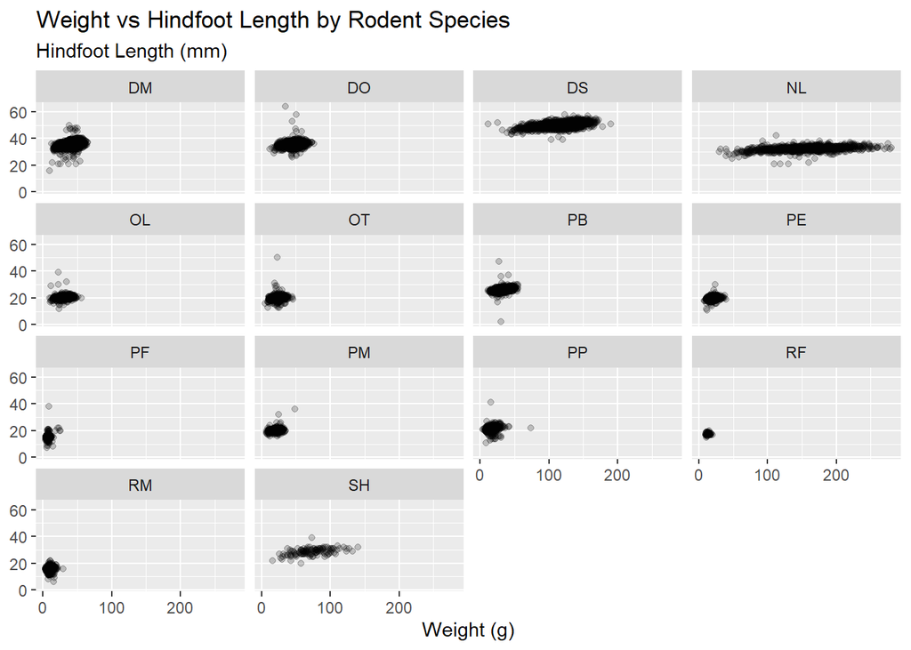

```r
ggplot(data = survey_data,
       mapping = aes(x = weight,
                     y = hindfoot_length)) +
  geom_point(alpha = 0.2) +
  facet_wrap(~ species_id) +
  labs(
    title = "Weight vs Hindfoot Length by Rodent Species",
    subtitle = "Hindfoot Length (mm)",
    x = "Weight (g)",
    y = NULL
  )
```

## Boxplots

**9. Sketch out (by hand or using [Excalidraw](https://excalidraw.com/)) a game plan for creating side-by-side boxplots to visualize the distribution of weight within each species. Include an image of your game plan.**

# Initial Boxplot Design

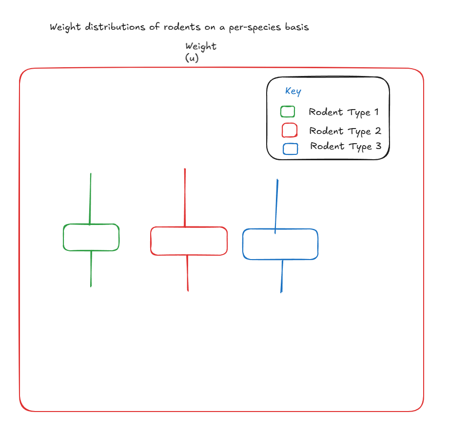

Initial Boxplot Design

**10. Implement your game plan to create side-by-side boxplots to visualize the distribution of weight within each species.**

**11. Add another layer to your previous plot that plots each observation.**

**12. Remove the previous layer and include a `geom_jitter()` layer instead. (You can overwrite your code for Q11)**

**13. Set the `color` aesthetic in `geom_jitter()` to change the color of the points and add set the `alpha` aesthetic to add transparency.**

**14. Inspect the help file for `geom_boxplot()` and see how you can remove the outliers from being plotted by `geom_boxplot()`. Make this change in your code!**

**15. Modify the $x$-axis and $y$-axis labels to describe what is being plotted. Be sure to include any necessary units! You might also be getting overlap in the species names – use `theme(axis.text.x = ____)` or `theme(axis.text.y = ____)` to turn the species axis labels 45 degrees. (You will need to look at the documentation or Google to find the syntax for this!)**

Note: For the y axis title I made it a subtitle as done previously in #8. This is for the sake of consistency with the previous plot.

# Weight distributions of rodents on a per-species basis (#10-#15)

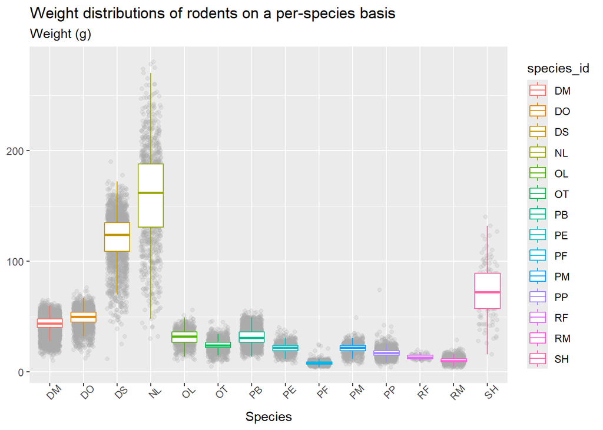

```r
# I just use these to make it look a bit cleaner.
jitter_height_constant = 0.1
jitter_width_constant = 0.3
ggplot(data = survey_data,
       mapping = aes( x = species_id,
         y = weight,
         color = species_id)) +
  geom_jitter(height = jitter_height_constant,
            width = jitter_width_constant,
            color = "darkgray",
            alpha = 0.2) +
  geom_boxplot( outliers = FALSE) +
  labs(
    title = "Weight distributions of rodents on a per-species basis",
    subtitle = "Weight (g)",
    x = "Species",
    y = NULL
  ) +
  theme(axis.text.x = element_text(angle = 45))
```

**16. Copy-paste your boxplot code from above. Flip the orientation of your boxplots. If you created horizontally stacked boxplots, your boxplots should now be stacked vertically. If you had vertically stacked boxplots, you should now stack your boxplots horizontally!**

Note: Again, made the species label a subtitle to be consistent with #8.

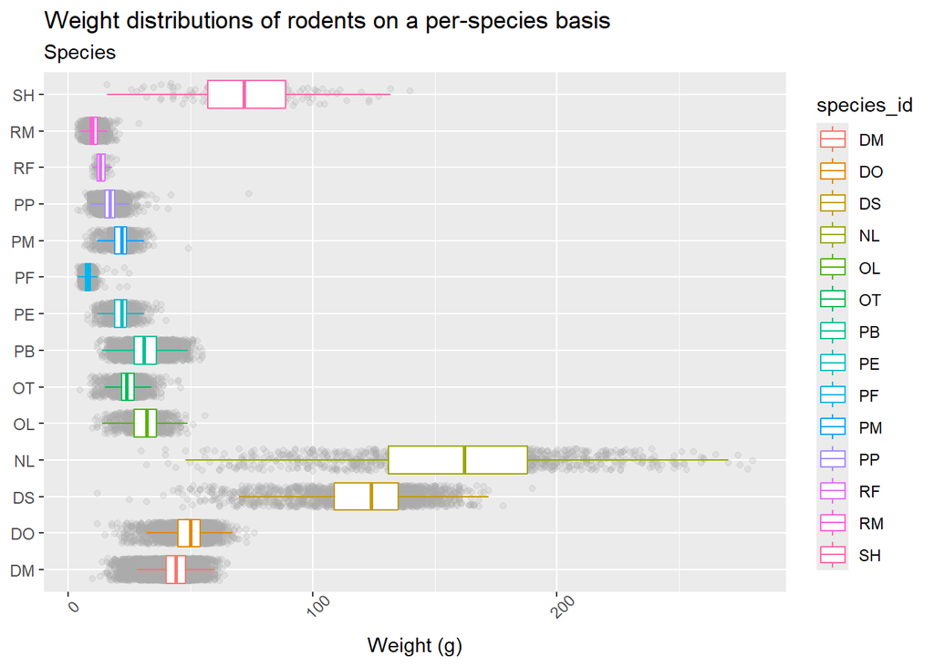

```r
# I just use these to make it look a bit cleaner.
jitter_height_constant = 0.1
jitter_width_constant = 0.3
ggplot(data = survey_data,
       mapping = aes( x = species_id,
         y = weight,
         color = species_id)) +
  geom_jitter(height = jitter_height_constant,
            width = jitter_width_constant,
            color = "darkgray",
            alpha = 0.2) +
  geom_boxplot( outliers = FALSE) +
  labs(
    title = "Weight distributions of rodents on a per-species basis",
    subtitle = "Species",
    x = NULL,
    y = "Weight (g)"
  ) +
  theme(axis.text.x = element_text(angle = 45)) +
  coord_flip()
```

# Statistical Analysis

**NoteNull Hypothesis**

The population mean weight is **the same** between **all** fourteen rodent species.

**NoteAlternative Hypothesis**

**At least one** rodent species has a different population mean weight.

Look up the help documentation for `aov()`.

**17. Using `aov()`, complete the code below to carry out the analysis.**

```r
species_mod <- aov(weight ~ species_id, data = survey_data)
summary(species_mod)
```

```
               Df   Sum Sq Mean Sq F value Pr(>F)
species_id     13 34786303 2675869   19916 <2e-16 ***
Residuals   30449  4091063     134
---
Signif. codes:  0 '***' 0.001 '**' 0.01 '*' 0.05 '.' 0.1 ' ' 1
```

**18. Based on the results of the ANOVA F-test, draw a conclusion in context of the hypotheses. Make sure to cite appropriate output from above.**

The P value given is incredibly close to 0. This means that the null hypothesis can be rejected even at a 99% level of certainty, meaning that at least one rodent species has a different population mean weight.

**19. Using the `species_mod` from above and the `emmeans()` function, complete the code below to obtain estimated model mean rodent weights for each species**

```r
species_estimates <- emmeans(species_mod, ~ species_id)
species_estimates
```

```
 species_id  emmean    SE    df lower.CL upper.CL
 DM          43.136 0.118 30449   42.906   43.366
 DO          48.867 0.219 30449   48.437   49.298
 DS         120.226 0.258 30449  119.721  120.732
 NL         158.785 0.359 30449  158.082  159.488
 OL          31.328 0.385 30449   30.573   32.083
 OT          24.217 0.254 30449   23.719   24.715
 PB          31.740 0.219 30449   31.311   32.169
 PE          21.577 0.335 30449   20.920   22.233
 PF           7.956 0.302 30449    7.363    8.549
 PM          21.341 0.401 30449   20.555   22.128
 PP          17.188 0.213 30449   16.771   17.605
 RF          13.479 1.360 30449   10.820   16.139
 RM          10.583 0.236 30449   10.121   11.045
 SH          73.031 1.020 30449   71.023   75.039

Confidence level used: 0.95
```

**20. Now that you have obtained the estimated model mean rodent weights, conduct pairwise comparisons using the `pairs()` function from the `emmeans` package.**

```r
pairs(species_estimates)
```

**Show pairwise comparisons**

```
 contrast estimate    SE    df  t.ratio p.value
 DM - DO    -5.731 0.249 30449  -23.023 <0.0001
 DM - DS   -77.090 0.283 30449 -272.168 <0.0001
 DM - NL  -115.649 0.377 30449 -306.485 <0.0001
 DM - OL    11.808 0.403 30449   29.312 <0.0001
 DM - OT    18.919 0.280 30449   67.577 <0.0001
 DM - PB    11.396 0.248 30449   45.862 <0.0001
 DM - PE    21.559 0.355 30449   60.745 <0.0001
 DM - PF    35.180 0.324 30449  108.427 <0.0001
 DM - PM    21.795 0.418 30449   52.141 <0.0001
 DM - PP    25.948 0.243 30449  106.766 <0.0001
 DM - RF    29.657 1.360 30449   21.779 <0.0001
 DM - RM    32.553 0.263 30449  123.567 <0.0001
 DM - SH   -29.895 1.030 30449  -28.989 <0.0001
 DO - DS   -71.359 0.338 30449 -210.819 <0.0001
 DO - NL  -109.917 0.420 30449 -261.464 <0.0001
 DO - OL    17.539 0.443 30449   39.555 <0.0001
 DO - OT    24.650 0.336 30449   73.420 <0.0001
 DO - PB    17.127 0.310 30449   55.253 <0.0001
 DO - PE    27.291 0.400 30449   68.161 <0.0001
 DO - PF    40.912 0.374 30449  109.490 <0.0001
 DO - PM    27.526 0.457 30449   60.201 <0.0001
 DO - PP    31.679 0.306 30449  103.652 <0.0001
 DO - RF    35.388 1.370 30449   25.750 <0.0001
 DO - RM    38.284 0.322 30449  118.859 <0.0001
 DO - SH   -24.164 1.050 30449  -23.062 <0.0001
 DS - NL   -38.558 0.442 30449  -87.320 <0.0001
 DS - OL    88.898 0.464 30449  191.778 <0.0001
 DS - OT    96.009 0.362 30449  265.284 <0.0001
 DS - PB    88.486 0.338 30449  261.674 <0.0001
 DS - PE    98.650 0.423 30449  233.451 <0.0001
 DS - PF   112.271 0.397 30449  282.557 <0.0001
 DS - PM    98.885 0.477 30449  207.400 <0.0001
 DS - PP   103.038 0.334 30449  308.343 <0.0001
 DS - RF   106.747 1.380 30449   77.302 <0.0001
 DS - RM   109.643 0.349 30449  313.902 <0.0001
 DS - SH    47.195 1.060 30449   44.673 <0.0001
 NL - OL   127.457 0.526 30449  242.156 <0.0001
 NL - OT   134.567 0.439 30449  306.202 <0.0001
 NL - PB   127.045 0.420 30449  302.397 <0.0001
```

[output cut: 39 more lines]

```
 PF - RF    -5.524 1.390 30449   -3.974  0.0055
 PF - RM    -2.628 0.383 30449   -6.852 <0.0001
 PF - SH   -65.076 1.070 30449  -60.919 <0.0001
 PM - PP     4.153 0.454 30449    9.147 <0.0001
 PM - RF     7.862 1.410 30449    5.557 <0.0001
 PM - RM    10.758 0.465 30449   23.121 <0.0001
 PM - SH   -51.690 1.100 30449  -46.980 <0.0001
 PP - RF     3.708 1.370 30449    2.701  0.2783
 PP - RM     6.605 0.318 30449   20.798 <0.0001
 PP - SH   -55.843 1.050 30449  -53.368 <0.0001
 RF - RM     2.896 1.380 30449    2.103  0.6994
 RF - SH   -59.552 1.700 30449  -35.029 <0.0001
 RM - SH   -62.448 1.050 30449  -59.400 <0.0001

P value adjustment: tukey method for comparing a family of 14 estimates
```

**21. Create the *ugliest version* of a scatterplot showing the relationship between `weight` and `hindfoot_length` (where you started in Q4). Then, *explain why* you made the decisions you did, and which principles of good graphics you’ve intentionally violated.**

The below scatter plot is terrible. It puts all the types onto one scatter plot and the differentiation is color. Some colors look incredibly similar to others. Also the plot doesn’t have units. The alpha is really high so elements can stack on each other, making some species hard or impossible to see in some locations. It is impossible to see the density of points, so whatever ends up on the top is essentially random. I also made the hindfoot length text directly on the y axis and also removed the title to make things more confusing. The axis elements also have their default names. I also made sure to not use geom jitter to make sure everything stacks up on each other as much as possible. By doing these things a lot of the things on the scatterplot have become unclear, obfuscated, and hard to see. The labels and points are unclear and its hard to gather any meaningful results.

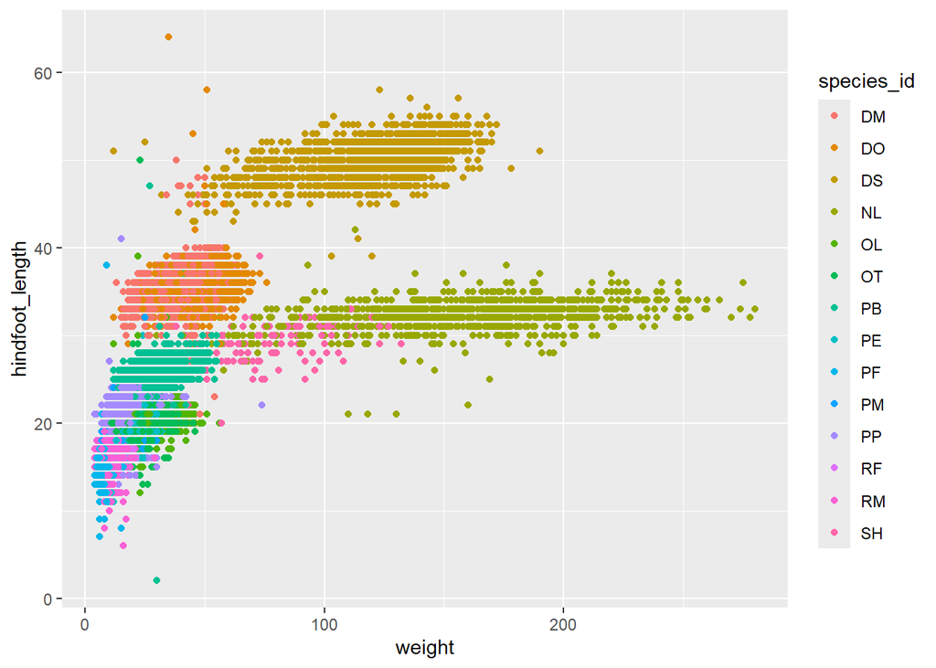

```r
ggplot(data = survey_data,
       mapping = aes(x = weight,
                     y = hindfoot_length,
                     color = species_id)) +
  geom_point(alpha = 1.5)
```